# Data 622 - Final Project (Group 2)

Predicting Heart Disease

Mengqin Cai, Zhi Ying Chen, Donny Lofland, Zach Alexander

5/19/2021

Source Code: https://github.com/djlofland/DATA622_S2021_Group2/tree/master/FinalProject

## **Load Data & EDA**

### Information about the dataset

Before loading our dataset, and discussing our data exploration process, We’ll quickly summarize the dataset that we’ll be using for our machine learning analysis. The dataset is part of **UCI’s Cleveland Heart Disease** data file, which consists of 303 individuals and various health-related metrics. The dataset we’ll be using includes 14 attributes retrieved from patient tests and can be used for machine learning and classification analysis. Ultimately, these attributes will be examined to determine their effectiveness at predicting whether or not a particular patient has Heart Disease. You can find more information about these 14 attributes below:

### Exploratory Data Analysis

First, we can check the shape of the dataset. It looks like there are 303 rows and 14 columns in our imported data. We also show the first few rows of data just to sanity check that things look correct.

```r
df <- read.csv("./data/heart.csv", header = TRUE)

dim(df)
```

```
## [1] 303  14
```

```r
kable(head(df))
```

| age | sex | cp | trestbps | chol | fbs | restecg | thalach | exang | oldpeak | slope | ca | thal | target |
| --- | --- | --- | --- | --- | --- | --- | --- | --- | --- | --- | --- | --- | --- |
| 63 | 1 | 3 | 145 | 233 | 1 | 0 | 150 | 0 | 2.3 | 0 | 0 | 1 | 1 |
| 37 | 1 | 2 | 130 | 250 | 0 | 1 | 187 | 0 | 3.5 | 0 | 0 | 2 | 1 |
| 41 | 0 | 1 | 130 | 204 | 0 | 0 | 172 | 0 | 1.4 | 2 | 0 | 2 | 1 |
| 56 | 1 | 1 | 120 | 236 | 0 | 1 | 178 | 0 | 0.8 | 2 | 0 | 2 | 1 |
| 57 | 0 | 0 | 120 | 354 | 0 | 1 | 163 | 1 | 0.6 | 2 | 0 | 2 | 1 |
| 57 | 1 | 0 | 140 | 192 | 0 | 1 | 148 | 0 | 0.4 | 1 | 0 | 1 | 1 |

### Missing values in the dataset

Missing values can be problematic if present. We can also check to see if there is missing data.

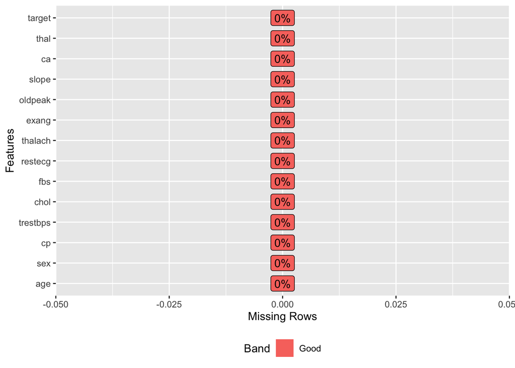

```r
plot_missing(df)
```

As we can see above, there aren’t any missing values across our dataset, which will make it easier for us as we start to prepare our dataset for machine learning analysis.

As a next steps, let’s convert known categorical features into `factor` data type, then show a summary of our dataframe.

```r
df_viz <- df %>%
  mutate(sex = if_else(sex == 1, "Male", "Female"),
         fbs = ordered(fbs, levels=c(0, 1), labels=c("<=120", ">120")),
         exang = if_else(exang == 1, "Yes" ,"No"),
         cp = if_else(cp == 1, "Atypical Angina",
                      if_else(cp == 2, "Non-anginal pain", "Asymptomatic")),
         restecg = if_else(restecg == 0, "Normal",
                           if_else(restecg == 1, "Abnormality", "probable or definite")),
         slope = ordered(slope,
                         levels=c(2, 1, 0),
                         labels=c('down', 'flat', 'up')),
         ca = ordered(ca,
                      levels=c(0, 1, 2, 3, 4),
                      labels=c(0, 1, 2, 3, 4)),
         thal = as.factor(thal),
         target = if_else(target == 1, "Has heart disease", "Does not have heart disease")) %>%
  mutate_if(is.character, as.factor) %>%
  dplyr::select(target, sex, fbs, exang, cp, restecg, slope, ca, thal, everything())
```

Next, we’ll look at a full summary of our features, including rudimentary distributions of each of our continuous variables:

```r
skimr::skim(df_viz)
```

Data summary

| Name | df_viz |
| --- | --- |
| Number of rows | 303 |
| Number of columns | 14 |
| _______________________ |  |
| Column type frequency: |  |
| factor | 9 |
| numeric | 5 |
| ________________________ |  |
| Group variables | None |

**Variable type: factor**

| skim_variable | n_missing | complete_rate | ordered | n_unique | top_counts |
| --- | --- | --- | --- | --- | --- |
| target | 0 | 1 | FALSE | 2 | Has: 165, Doe: 138 |
| sex | 0 | 1 | FALSE | 2 | Mal: 207, Fem: 96 |
| fbs | 0 | 1 | TRUE | 2 | <=1: 258, >12: 45 |
| exang | 0 | 1 | FALSE | 2 | No: 204, Yes: 99 |
| cp | 0 | 1 | FALSE | 3 | Asy: 166, Non: 87, Aty: 50 |
| restecg | 0 | 1 | FALSE | 3 | Abn: 152, Nor: 147, pro: 4 |
| slope | 0 | 1 | TRUE | 3 | dow: 142, fla: 140, up: 21 |
| ca | 0 | 1 | TRUE | 5 | 0: 175, 1: 65, 2: 38, 3: 20 |
| thal | 0 | 1 | FALSE | 4 | 2: 166, 3: 117, 1: 18, 0: 2 |

**Variable type: numeric**

| skim_variable | n_missing | complete_rate | mean | sd | p0 | p25 | p50 | p75 | p100 | hist |
| --- | --- | --- | --- | --- | --- | --- | --- | --- | --- | --- |
| age | 0 | 1 | 54.37 | 9.08 | 29 | 47.5 | 55.0 | 61.0 | 77.0 | ▁▆▇▇▁ |
| trestbps | 0 | 1 | 131.62 | 17.54 | 94 | 120.0 | 130.0 | 140.0 | 200.0 | ▃▇▅▁▁ |
| chol | 0 | 1 | 246.26 | 51.83 | 126 | 211.0 | 240.0 | 274.5 | 564.0 | ▃▇▂▁▁ |
| thalach | 0 | 1 | 149.65 | 22.91 | 71 | 133.5 | 153.0 | 166.0 | 202.0 | ▁▂▅▇▂ |
| oldpeak | 0 | 1 | 1.04 | 1.16 | 0 | 0.0 | 0.8 | 1.6 | 6.2 | ▇▂▁▁▁ |

Looking at our `target`, there is a reasonable class balance between the presence and absence of heart disease. However, we do see value class imbalance when looking at several of the factor features: `fbs`, `exang`, `cp`, `restecg`, `slop`, `ca`, and `thal`.

While `age` looks normally distributed, there is apparent right-skew in `trestbps`, `chol`, and `oldpeak`. `thalach` is left skewed. Our continuous features are also on different scales. We will want to transform and normalize these ahead of modeling.

Let’s visualize our `target` distribution.

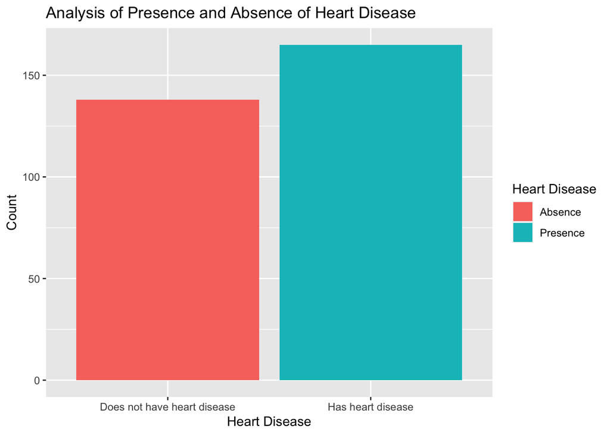

```r
# Bar plot for target (Heart disease)
ggplot(df_viz, aes(x=target, fill=target)) +
  geom_bar() +
  xlab("Heart Disease") +
  ylab("Count") +
  ggtitle("Analysis of Presence and Absence of Heart Disease") +
  scale_fill_discrete(name = "Heart Disease", labels = c("Absence", "Presence"))
```

```r
prop.table(table(df_viz$target))
```

```
##
## Does not have heart disease           Has heart disease
##                   0.4554455                   0.5445545
```

We can see that there is roughly a 50/50 split in this dataset of those that do have heart disease from those that do not have heart disease. This will come in handy later when we set up our machine learning analyses.

Additionally, when looking at the summary distributions, we can see that our patient population skews above 50 years, with an average age of individuals in this dataset at about 54 years old. The oldest individual is 77 years old, and the youngest is 29. We can take a look at the age frequency counts here:

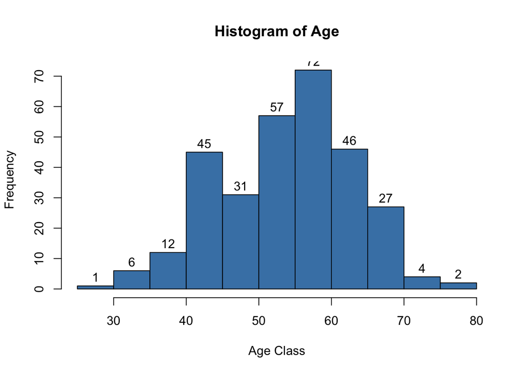

```r
# Counting the frequency of the values of the age
hist(df_viz$age, labels=TRUE, main="Histogram of Age", xlab="Age Class",
     ylab="Frequency", col="steelblue")
```

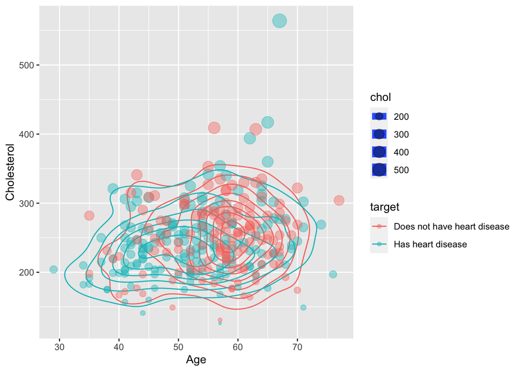

```r
df_viz %>%
  ggplot(aes(x=age, y=chol, size=chol, color=target)) +
  geom_density2d() +
  geom_point(alpha=0.4) +
  xlab("Age") +
  ylab("Cholesterol")
```

```r
df %>%
  group_by(target) %>%
  summarise(mean=mean(trestbps))
```

```
## # A tibble: 2 x 2
##   target  mean
##    <int> <dbl>
## 1      0  134.
## 2      1  129.
```

### Feature Plots

Next, we explore the relationships between each feature and the target. For our continuous features, we do a simple `featurePlot` from the `caret` package which also lets us see how pairs of features relate with the target.

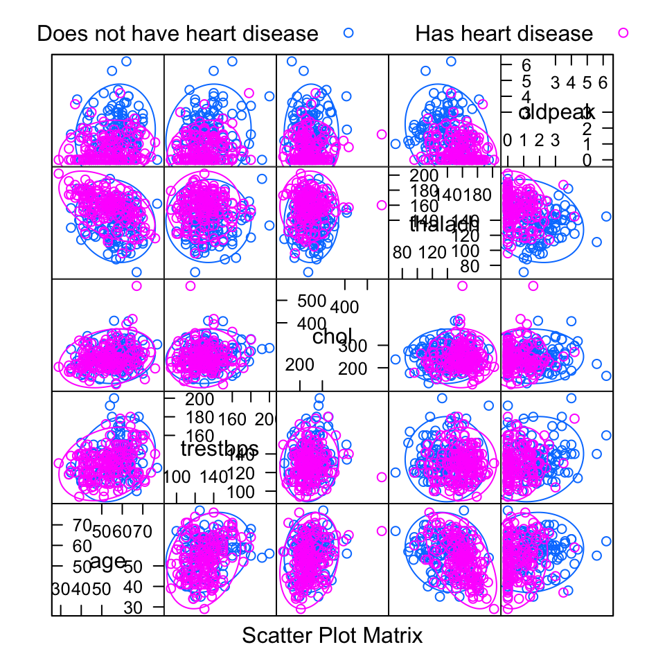

```r
featurePlot(x=df_viz[,c(10, 11, 12, 13, 14)], y=df_viz[, 1],
            plot = "ellipse",
            auto.key = list(columns = 2))
```

For the continuous variables, we can also examine the correlations, broken out by the target variable.

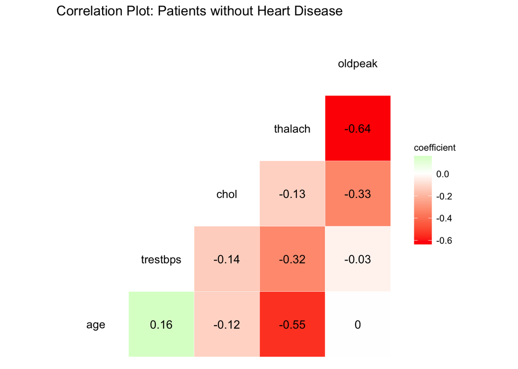

```r
wo_hd <- df_viz %>%
  filter(target == 'Does not have heart disease') %>%
  select(age, trestbps, chol, thalach, oldpeak)

cor_heart_wo <- cor(wo_hd)

ggcorr(cor_heart_wo, label = T, label_round = 2) +
  scale_fill_gradient2(low='#ff0000', mid='#ffffff', high='#00ff00',
                        midpoint=0, guide = "colourbar", aesthetics = "fill") +
  ggtitle('Correlation Plot: Patients without Heart Disease')
```

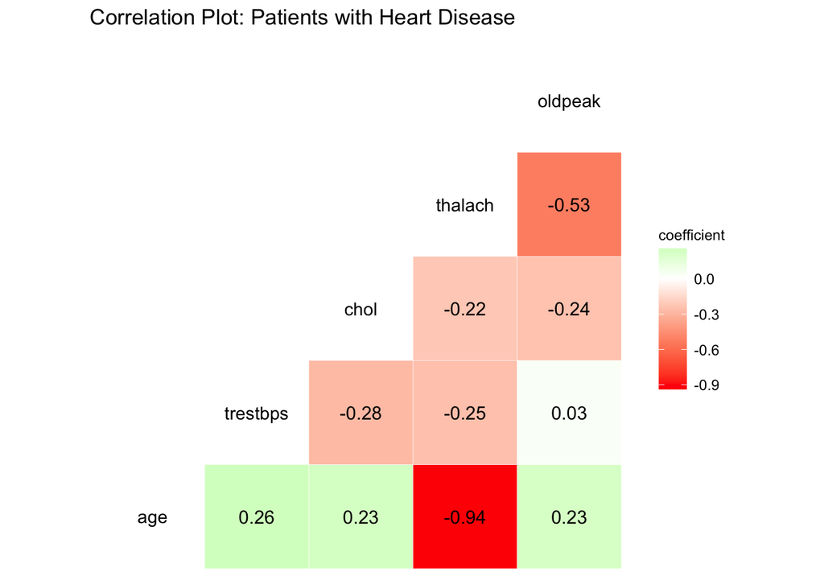

```r
wi_hd <- df_viz %>%
  filter(target == 'Has heart disease') %>%
  select(age, trestbps, chol, thalach, oldpeak)

cor_heart_wi <- cor(wi_hd)

ggcorr(cor_heart_wi, label = T, label_round = 2) +
  scale_fill_gradient2(low='#ff0000', mid='#ffffff', high='#00ff00',
                        midpoint=0, guide = "colourbar", aesthetics = "fill") +
  ggtitle('Correlation Plot: Patients with Heart Disease')
```

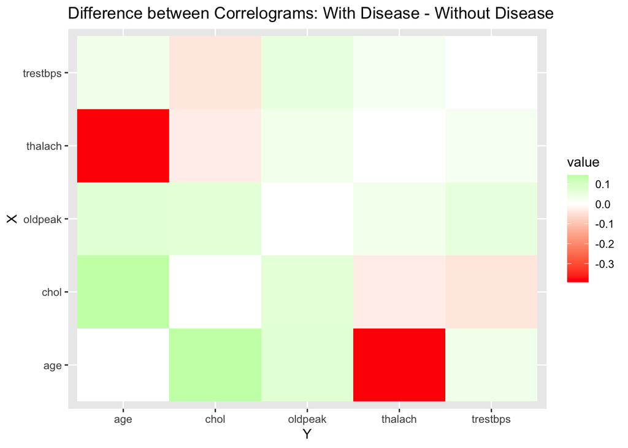

```r
cor_heart_delta = cor_heart_wi - cor_heart_wo

delta_df <- as.data.frame(cor_heart_delta)

delta_dfl <- delta_df %>%
  rownames_to_column(var="X") %>%
  pivot_longer(cols=-c(X), names_to='Y')

ggplot(delta_dfl, aes(X, Y, fill=value)) +
  geom_tile() +
  coord_flip() +
  scale_fill_gradient2(low='#ff0000', mid='#ffffff', high='#00ff00',
                        midpoint=0, guide = "colourbar", aesthetics = "fill") +
  ggtitle('Difference between Correlograms: With Disease - Without Disease')
```

We separate out the correleograms based on `target` class. The first chart show the pairwise correlations between continuous variable in our Healthy patients. The second chart shows the pairwise correlations in patients with heart disease. The third chart sows the difference to help draw attention to how heart disease patients differ from healthy patients. For example, `age` vs. `thalach` correlation in healthy patients is `-0.55`. In heart diseased patients, the correlation is `-0.94` … there is a much stronger negative correlation between these features in our diseased patients. The third chart show a bright red filled for `age` vs. `thalach` to draw attention that this correlation became more negative. As a counter example, the `age` vs. `cholesterol` correlation is higher in diseased patients vs healthy (0.23 > -0.12). This increase in correlation shows as a light green tile in the Difference plot (third).

We can use bar charts to visualize how our categorical features are distribute across the two target classes.

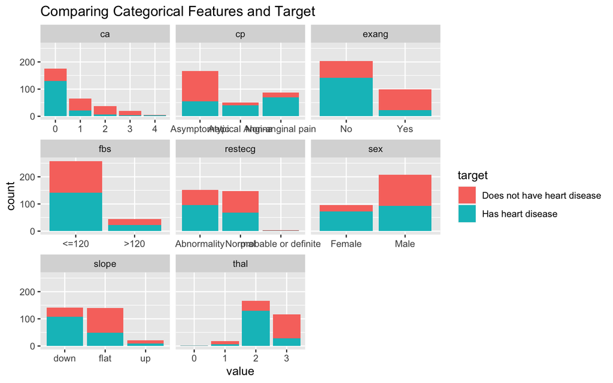

```r
long_df <- df_viz %>%
  select(c(target:thal)) %>%
  mutate(fbs = factor(as.character(fbs)),
         ca = factor(as.character(ca)),
         thal = factor(as.character(thal)),
         slope = factor(as.character(slope))) %>%
  pivot_longer(cols=-c(target), names_to='kpi')

ggplot(long_df, aes(x=value, fill=target)) +
  geom_bar() +
  facet_wrap(~kpi, scales="free_x") +
  ggtitle('Comparing Categorical Features and Target')
```

A few notable points:

- Looking as `sex`, we now see that of the patients in this study, a far higher portion of `female` presented with heat disease compared with the `males`.
- `exang` of `No` is more common with having heart disease.
- As we would expect, `cp` = `Asymptomatic` is far more correlated with being healthy.

### Dummy Columns

We’ll need to dummy code our categorical variables. This process will create new columns for each value and assign a 0 or 1. Note that dummy encoding typically drops one value which becomes the baseline. So if we have a categorical feature with five unique values, we will have four columns. If all columns are 0, that represents the reference value. This helps reduce the number of necessary columns. With dummy columns in place, we need to remove our original variables from this dataset.

```r
# dummy encode our categorical features
df_dummy <- dummyVars(~ ., fullRank=T, drop2nd=T, data=df_viz)
df_dummy <- data.frame(predict(df_dummy, newdata=df_viz))

df_dummy <- df_dummy %>%
  mutate(target = as.factor(target.Has.heart.disease)) %>%
  select(-target.Has.heart.disease)
```

## Splitting the Dataset into Training and Testing

Our first step will be to separate the data into training and test dataset. This way, we can test the accuracy by using our holdout test set later on. We decided to perform a conventional 80/20 training to testing data split on dummied dataset.

```r
set.seed(123)

index    <- createDataPartition(df_dummy$target, p=0.8, list = FALSE)

df_train <- df_dummy[index,]
df_test  <- df_dummy[-index,]
```

With our dataset prepared and training/test split in place, we re ready to proceed with trying different machine learning models to predict heart disease given our feature.

## Supervised Machine Learning

### Random Forest Analysis

Random forest is a Supervised Learning algorithm which uses ensemble learning method for classification and regression. It is a bagging technique and not a boosting technique. The trees in random forests are run in parallel. There is no interaction between these trees while building the trees. It operates by constructing a multitude of decision trees at training time and outputting the class that is the mode of the classes (classification) or mean prediction (regression) of the individual trees.

```r
set.seed(123)
fit.forest <- randomForest(target ~ ., data = df_train, importance=TRUE, ntree=2000)

# display model details
fit.forest
```

```
##
## Call:
##  randomForest(formula = target ~ ., data = df_train, importance = TRUE,      ntree = 2000)
##                Type of random forest: classification
##                      Number of trees: 2000
## No. of variables tried at each split: 4
##
##         OOB estimate of  error rate: 16.87%
## Confusion matrix:
##    0   1 class.error
## 0 93  18   0.1621622
## 1 23 109   0.1742424
```

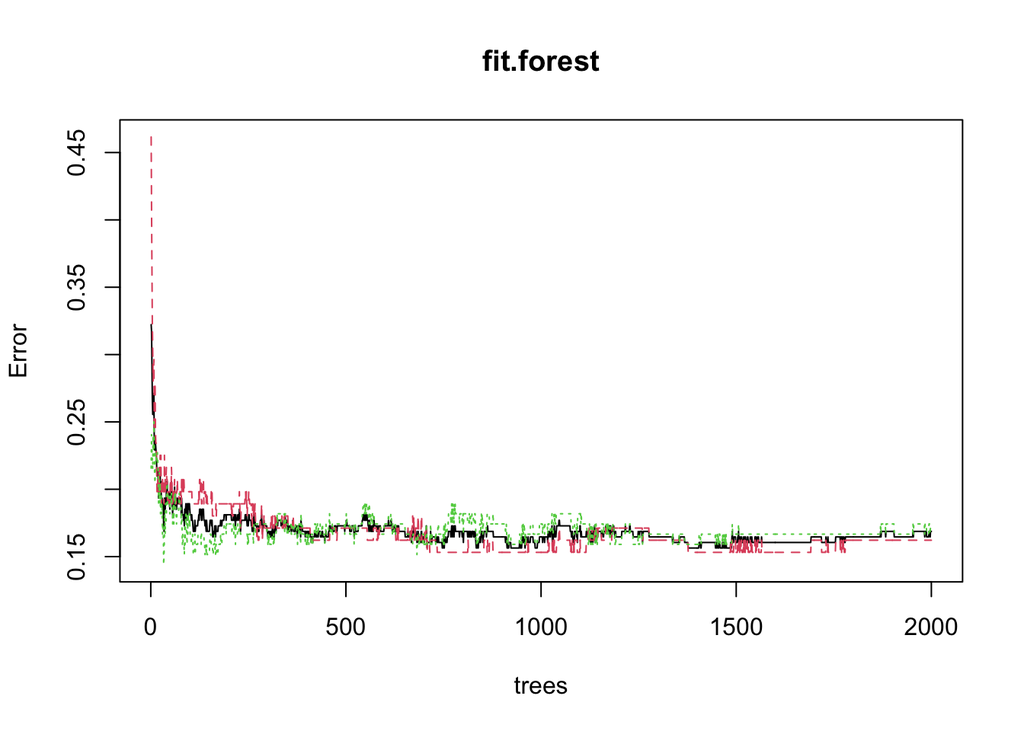

```r
plot(fit.forest)
```

Red line represents MCR of class not having heart diseases, green line represents MCR of class having heart diseases and black line represents overall MCR or OOB error. Overall error rate is what we are interested in which seems considerably good.

```r
# show which feature were most important
importance(fit.forest)
```

```
##                                       0          1 MeanDecreaseAccuracy
## sex.Male                      9.0704704 25.0338607           24.4119583
## fbs.L                        -0.9344651  0.4164734           -0.3184235
## exang.Yes                    11.9277558 10.5587409           15.1351725
## cp.Atypical.Angina            5.2528497  0.4315867            4.0363058
## cp.Non.anginal.pain          17.2381156  7.3229993           16.9461636
## restecg.Normal                3.2540965  4.8975554            5.8390767
## restecg.probable.or.definite -1.2655302 -3.8634344           -4.0848817
## slope.L                      12.9774985  2.8493332           11.4015972
## slope.Q                       2.1566005  1.9906048            3.1049258
## ca.L                         21.8928226 20.1368599           26.8148332
## ca.Q                         24.6405370 27.4469281           34.6635740
## ca.C                         11.4421390 17.7668713           20.6168641
## ca.4                          8.6745184 15.6614353           16.6657480
## thal.1                       -1.5445887  5.3702696            2.6987890
## thal.2                       23.9738640 25.4875592           31.5974142
## thal.3                       20.4695216 22.4645270           27.7900762
## age                           5.5165381  6.3363017            8.5017674
## trestbps                      1.7600099  0.7345711            1.9188623
## chol                         -5.0859014  6.7756548            1.8362207
## thalach                      14.4557134 23.3814674           26.9555574
## oldpeak                      20.3630123 17.6957179           26.2933800
##                              MeanDecreaseGini
## sex.Male                            3.9605866
## fbs.L                               1.1401556
## exang.Yes                           5.3811409
## cp.Atypical.Angina                  1.3364486
## cp.Non.anginal.pain                 3.7908046
## restecg.Normal                      2.3829847
## restecg.probable.or.definite        0.1479234
## slope.L                             3.3942602
## slope.Q                             1.9938619
## ca.L                                7.9996782
## ca.Q                               10.6301479
## ca.C                                3.9869417
## ca.4                                3.2525415
## thal.1                              0.6340835
## thal.2                             11.2929543
## thal.3                              7.8552130
## age                                 7.9787206
## trestbps                            6.9632178
## chol                                7.5964484
## thalach                            14.2977390
## oldpeak                            11.1235862
```

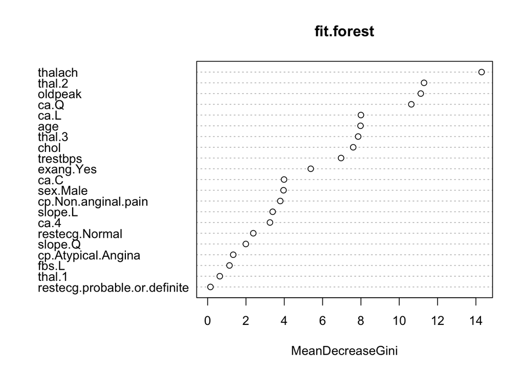

```r
varImpPlot(fit.forest,type=2)
```

After fitting our model, we can now use it to create predictions on our holdout test set to evaluate its performance.

```r
rf.pred <- predict(fit.forest, newdata=df_test, type = "class")
(forest.cm_train <- confusionMatrix(rf.pred, df_test$target))
```

```
## Confusion Matrix and Statistics
##
##           Reference
## Prediction  0  1
##          0 21  7
##          1  6 26
##
##                Accuracy : 0.7833
##                  95% CI : (0.658, 0.8793)
##     No Information Rate : 0.55
##     P-Value [Acc > NIR] : 0.0001472
##
##                   Kappa : 0.5638
##
##  Mcnemar's Test P-Value : 1.0000000
##
##             Sensitivity : 0.7778
##             Specificity : 0.7879
##          Pos Pred Value : 0.7500
##          Neg Pred Value : 0.8125
##              Prevalence : 0.4500
##          Detection Rate : 0.3500
##    Detection Prevalence : 0.4667
##       Balanced Accuracy : 0.7828
##
##        'Positive' Class : 0
##
```

```r
rf.perf <- c(forest.cm_train$overall[1],
             forest.cm_train$byClass[1],
             forest.cm_train$byClass[2],
             forest.cm_train$byClass[5],
             forest.cm_train$byClass[6],
             forest.cm_train$byClass[7])
```

### Gradient Boosting

```r
set.seed(123)

# build gradient boosted model
fit.boost <- gbm(target~., df_train,
             distribution = "gaussian",
             n.trees = 2000,
             cv.folds = 5)

# display model details
fit.boost
```

```
## gbm(formula = target ~ ., distribution = "gaussian", data = df_train,
##     n.trees = 2000, cv.folds = 5)
## A gradient boosted model with gaussian loss function.
## 2000 iterations were performed.
## The best cross-validation iteration was 82.
## There were 21 predictors of which 16 had non-zero influence.
```

```r
sqrt(min(fit.boost$cv.error))
```

```
## [1] 0.3548503
```

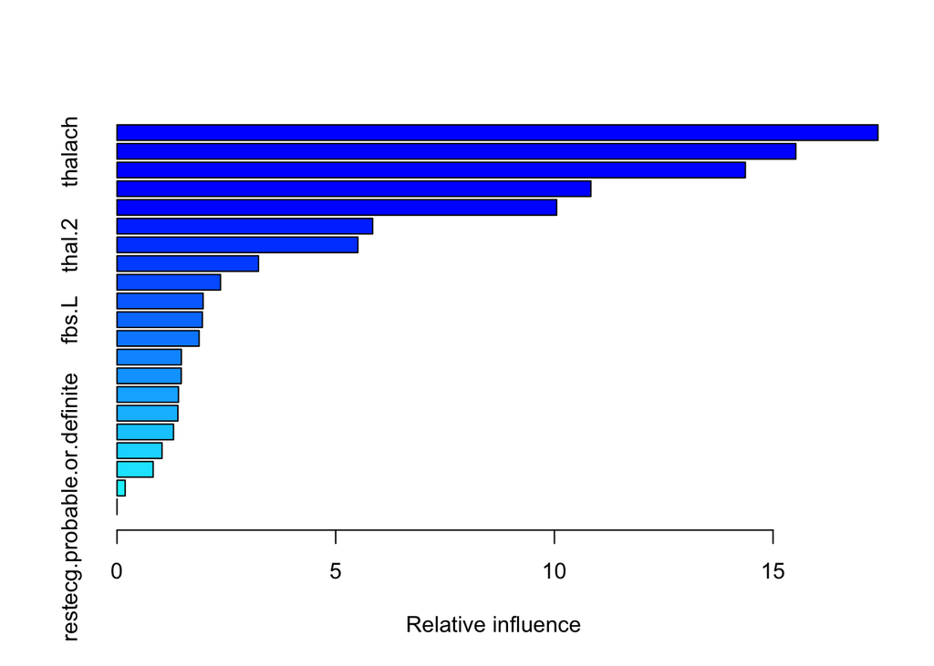

[output not shown]

```r
summary(fit.boost)
```

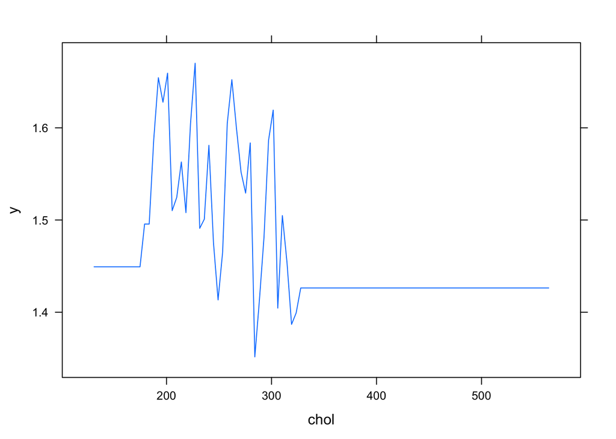

```r
plot(fit.boost, i="chol")
```

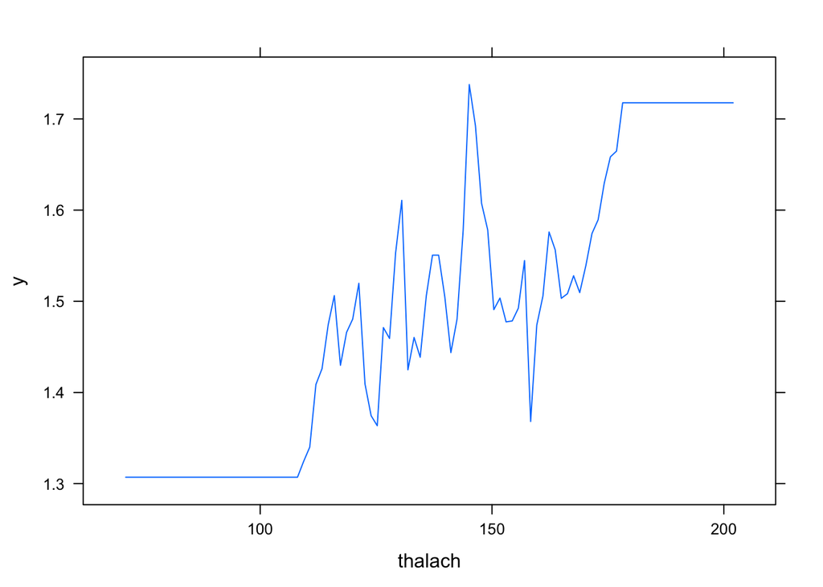

```r
plot(fit.boost, i="thalach")
```

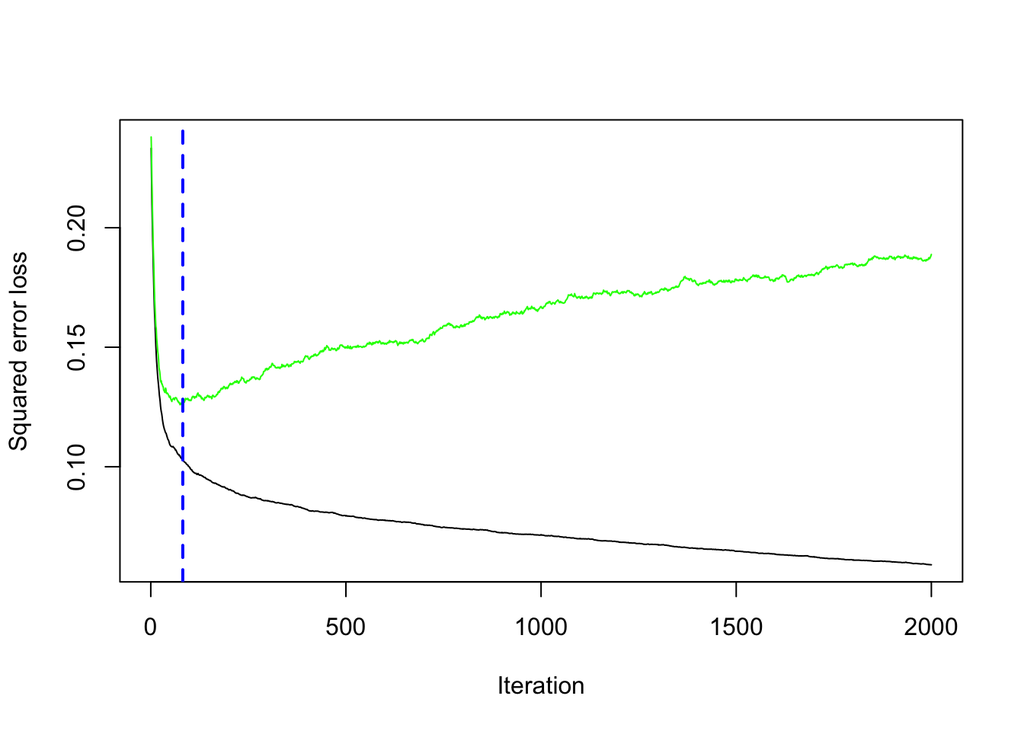

```
## [1] 82
```

```r
# plot loss function as a result of n trees added to the ensemble
gbm.perf(fit.boost, method = "cv")
```

```r
gbm.perf(fit.boost, method = "OOB")
```

```
## OOB generally underestimates the optimal number of iterations although predictive performance is reasonably competitive. Using cv_folds>1 when calling gbm usually results in improved predictive performance.
```

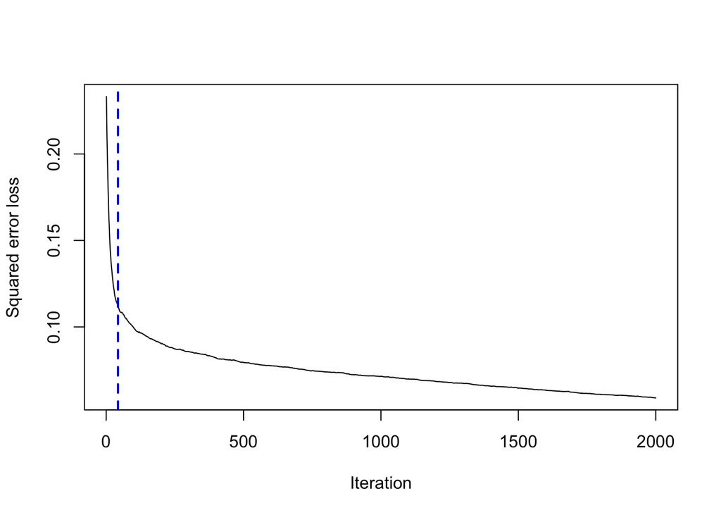

```
## [1] 43
## attr(,"smoother")
## Call:
## loess(formula = object$oobag.improve ~ x, enp.target = min(max(4,
##     length(x)/10), 50))
##
## Number of Observations: 2000
## Equivalent Number of Parameters: 39.99
## Residual Standard Error: 0.0003449
```

The plots indicating the optimum number of trees based on the technique we used. The green line indicates the error on the test data, and the blue dotted line points to the optimum number of iterations. We can observe that beyond a certain point (82 iterations for the cross-validation method and 43 for the OOB method), the test data error appears to increase because of overfitting.

```r
boostPre <- predict.gbm(fit.boost,
                        df_test,
                        n.trees = 42)
boostPre <- ifelse(boostPre < 1.5, 0, 1)

gbm.pred <- as.factor(boostPre)

(boost.cm <- confusionMatrix(gbm.pred, df_test$target))
```

```
## Confusion Matrix and Statistics
##
##           Reference
## Prediction  0  1
##          0 21  3
##          1  6 30
##
##                Accuracy : 0.85
##                  95% CI : (0.7343, 0.929)
##     No Information Rate : 0.55
##     P-Value [Acc > NIR] : 8.068e-07
##
##                   Kappa : 0.6939
##
##  Mcnemar's Test P-Value : 0.505
##
##             Sensitivity : 0.7778
##             Specificity : 0.9091
##          Pos Pred Value : 0.8750
##          Neg Pred Value : 0.8333
##              Prevalence : 0.4500
##          Detection Rate : 0.3500
##    Detection Prevalence : 0.4000
##       Balanced Accuracy : 0.8434
##
##        'Positive' Class : 0
##
```

```r
gbm.perf <- c(boost.cm$overall[1],
              boost.cm$byClass[1],
              boost.cm$byClass[2],
              boost.cm$byClass[5],
              boost.cm$byClass[6],
              boost.cm$byClass[7])
```

### Support Vector Machine

In machine learning, Support vector machine (SVM) are supervised learning models with associated learning algorithms that analyze data used for classification and regression analysis. It is mostly used in classification problems. In this algorithm, each data item is plotted as a point in n-dimensional space (where n is number of features), with the value of each feature being the value of a particular coordinate. Then, classification is performed by finding the hyper-plane that best differentiates the two classes.

In addition to performing linear classification, SVMs can efficiently perform a non-linear classification, implicitly mapping their inputs into high-dimensional feature spaces.

```r
set.seed(123)

fit.svm <- svm(target~.,
               data=df_train,
               kernel="radial",
               cost=10,
               scale = FALSE)
fit.svm
```

```
##
## Call:
## svm(formula = target ~ ., data = df_train, kernel = "radial", cost = 10,
##     scale = FALSE)
##
##
## Parameters:
##    SVM-Type:  C-classification
##  SVM-Kernel:  radial
##        cost:  10
##
## Number of Support Vectors:  242
```

```r
svm.pred <- predict(fit.svm,
                    newdata = df_test)

(svm.cm_train <- confusionMatrix(svm.pred, df_test$target))
```

```
## Confusion Matrix and Statistics
##
##           Reference
## Prediction  0  1
##          0  2  1
##          1 25 32
##
##                Accuracy : 0.5667
##                  95% CI : (0.4324, 0.6941)
##     No Information Rate : 0.55
##     P-Value [Acc > NIR] : 0.4502
##
##                   Kappa : 0.0476
##
##  Mcnemar's Test P-Value : 6.462e-06
##
##             Sensitivity : 0.07407
##             Specificity : 0.96970
##          Pos Pred Value : 0.66667
##          Neg Pred Value : 0.56140
##              Prevalence : 0.45000
##          Detection Rate : 0.03333
##    Detection Prevalence : 0.05000
##       Balanced Accuracy : 0.52189
##
##        'Positive' Class : 0
##
```

```r
svm.tune <- tune(e1071::svm, target~.,
                 data = df_train,
                 ranges=list(cost=c(0.001, 0.01, 0.1, 1, 5, 10, 100),
                 kernel=c("linear", "polynomial", "radial"),
                 gamma=c(0.5, 1, 2, 3, 4)))
```

```r
summary(svm.tune)
```

```
##
## Parameter tuning of 'e1071::svm':
##
## - sampling method: 10-fold cross validation
##
## - best parameters:
##  cost kernel gamma
##  0.01 linear   0.5
##
## - best performance: 0.1568333
##
## - Detailed performance results:
##      cost     kernel gamma     error dispersion
## 1   1e-03     linear   0.5 0.2098333 0.06563296
## 2   1e-02     linear   0.5 0.1568333 0.07804893
```

[output cut: 103 more lines]

```r
bestmod <- svm.tune$best.model
bestmod
```

```
##
## Call:
## best.tune(method = e1071::svm, train.x = target ~ ., data = df_train,
##     ranges = list(cost = c(0.001, 0.01, 0.1, 1, 5, 10, 100), kernel = c("linear",
##         "polynomial", "radial"), gamma = c(0.5, 1, 2, 3, 4)))
##
##
## Parameters:
##    SVM-Type:  C-classification
##  SVM-Kernel:  linear
##        cost:  0.01
##
## Number of Support Vectors:  131
```

```r
svm.pred2 <- predict(bestmod, newdata = df_test, type = "class")

(svm.cm_train2 <- confusionMatrix(svm.pred2, df_test$target))
```

```
## Confusion Matrix and Statistics
##
##           Reference
## Prediction  0  1
##          0 20  3
##          1  7 30
##
##                Accuracy : 0.8333
##                  95% CI : (0.7148, 0.9171)
##     No Information Rate : 0.55
##     P-Value [Acc > NIR] : 3.483e-06
##
##                   Kappa : 0.6587
##
##  Mcnemar's Test P-Value : 0.3428
##
##             Sensitivity : 0.7407
##             Specificity : 0.9091
##          Pos Pred Value : 0.8696
##          Neg Pred Value : 0.8108
##              Prevalence : 0.4500
##          Detection Rate : 0.3333
##    Detection Prevalence : 0.3833
##       Balanced Accuracy : 0.8249
##
##        'Positive' Class : 0
##
```

```r
svm.perf <- c(svm.cm_train2$overall[1],
              svm.cm_train2$byClass[1],
              svm.cm_train2$byClass[2],
              svm.cm_train2$byClass[5],
              svm.cm_train2$byClass[6],
              svm.cm_train2$byClass[7])
```

### Neural Network

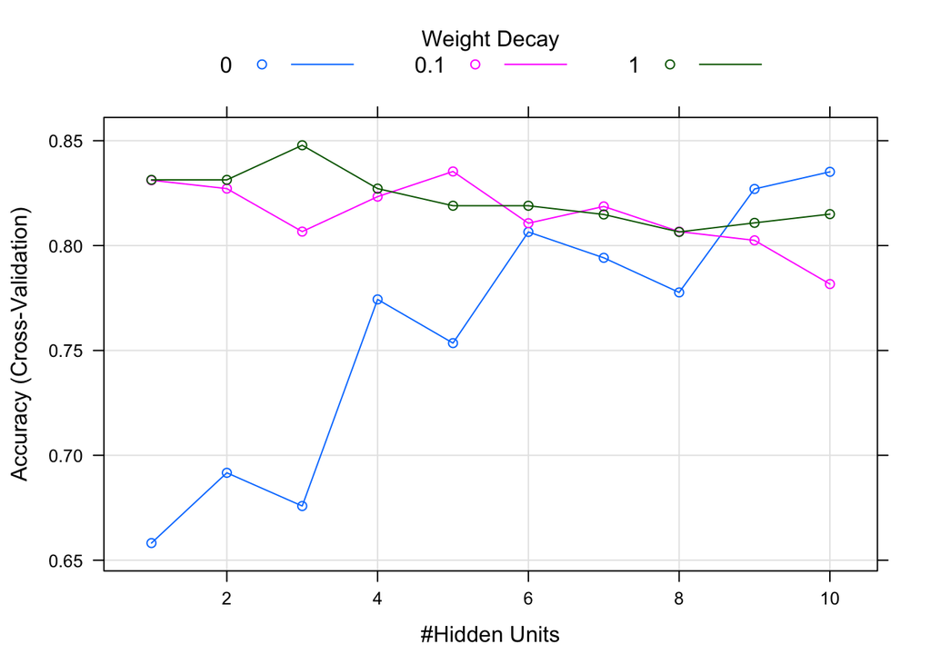

```r
set.seed(123)


## Create a specific candidate set of models to evaluate:
nnetGrid <- expand.grid(
  .decay = c(0, 0.1, 1),
  .size = c(1:10),
  ## The next option is to use bagging (see the
  ## next chapter) instead of different random
  ## seeds.
  .bag = FALSE)

ctrl <- trainControl(method='cv', number=10)

nnetModel <- train(df_train[, 1:21], df_train[, 22],
  method = "avNNet",
  tuneGrid = nnetGrid,
  trControl = ctrl,
  linout = TRUE,
  trace = FALSE,
  MaxNWts = 243,
  maxit = 500)

# Model results
plot(nnetModel)
```

```r
summary(nnetModel)
```

```
##             Length Class      Mode
## model        5     -none-     list
## repeats      1     -none-     numeric
## bag          1     -none-     logical
## seeds        5     -none-     numeric
## names       21     -none-     character
## terms        3     terms      call
## coefnames   21     -none-     character
## xlevels      0     -none-     list
## xNames      21     -none-     character
## problemType  1     -none-     character
## tuneValue    3     data.frame list
## obsLevels    2     -none-     character
## param        4     -none-     list
```

```r
varImp(nnetModel)
```

```
## ROC curve variable importance
##
##   only 20 most important variables shown (out of 21)
##
##                              Importance
## thalach                         100.000
## ca.Q                             99.835
## thal.2                           99.466
## oldpeak                          90.758
## ca.L                             90.605
## thal.3                           87.796
## exang.Yes                        75.515
## slope.L                          64.086
## slope.Q                          58.162
## sex.Male                         53.280
## cp.Non.anginal.pain              52.670
## ca.C                             51.195
## age                              42.080
## restecg.Normal                   35.660
## cp.Atypical.Angina               31.960
## ca.4                             25.108
## trestbps                         18.370
## chol                             17.480
## thal.1                           11.632
## restecg.probable.or.definite      1.907
```

```r
nn.pred <- predict(nnetModel, newdata = df_test[, 1:21])

(nn.cm_train <- confusionMatrix(nn.pred, df_test[, 22]))
```

```
## Confusion Matrix and Statistics
##
##           Reference
## Prediction  0  1
##          0 22  6
##          1  5 27
##
##                Accuracy : 0.8167
##                  95% CI : (0.6956, 0.9048)
##     No Information Rate : 0.55
##     P-Value [Acc > NIR] : 1.344e-05
##
##                   Kappa : 0.6309
##
##  Mcnemar's Test P-Value : 1
##
##             Sensitivity : 0.8148
##             Specificity : 0.8182
##          Pos Pred Value : 0.7857
##          Neg Pred Value : 0.8438
##              Prevalence : 0.4500
##          Detection Rate : 0.3667
##    Detection Prevalence : 0.4667
##       Balanced Accuracy : 0.8165
##
##        'Positive' Class : 0
##
```

```r
nn.perf <- c(nn.cm_train$overall[1],
             nn.cm_train$byClass[1],
             nn.cm_train$byClass[2],
             nn.cm_train$byClass[5],
             nn.cm_train$byClass[6],
             nn.cm_train$byClass[7])
```

### Multivariate Adaptive Regressive Splines (MARS)

One final model we will try is MARS. MARS has the advantage that it uses derived features so in effect has a built in dimensionality reduction steps.

```r
set.seed(123)

# Define the candidate models to test
marsGrid <- expand.grid(.degree = 1:2, .nprune = 2:38)

marsModel <- train(df_train[, 1:21], df_train[, 22],
  method = "earth",
  tuneGrid = marsGrid,
  trControl = trainControl(method = "cv"))
```

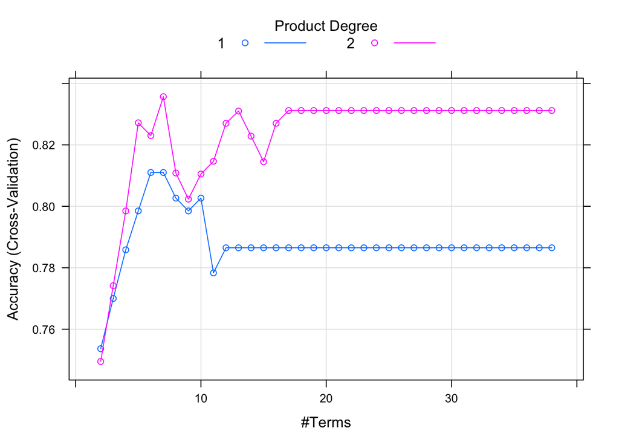

```r
# Model results
plot(marsModel)
```

```r
summary(marsModel)
```

```
## Call: earth(x=data.frame[243,21], y=factor.object, keepxy=TRUE,
##             glm=list(family=function.object, maxit=100), degree=2, nprune=7)
##
## GLM coefficients
##                                                 1
## (Intercept)                            -3.6874606
## thal.2                                  3.4439761
## h(ca.Q- -0.267261)                      4.8864816
## h(0.8-oldpeak)                          1.7065961
## sex.Male * thal.2                      -2.1573045
## cp.Non.anginal.pain * h(0.119523-ca.4)  4.5602942
## h(ca.Q- -0.267261) * h(157-thalach)    -0.0737735
##
## GLM (family binomial, link logit):
##  nulldev  df       dev  df   devratio     AIC iters converged
##  335.052 242   161.884 236      0.517   175.9     6         1
##
## Earth selected 7 of 33 terms, and 7 of 21 predictors (nprune=7)
## Termination condition: Reached nk 43
## Importance: thal.2, ca.Q, thalach, cp.Non.anginal.pain, ca.4, oldpeak, ...
## Number of terms at each degree of interaction: 1 3 3
## Earth GCV 0.1256132    RSS 26.63671    GRSq 0.4979246    RSq 0.5582364
```

```r
varImp(marsModel)
```

```
## earth variable importance
##
##                     Overall
## thal.2              100.000
## ca.Q                 59.626
## thalach              28.354
## ca.4                 17.959
## cp.Non.anginal.pain  17.959
## oldpeak               3.553
## sex.Male              0.000
```

```r
mars.pred <- predict(marsModel, newdata = df_test[, 1:21])

mars.cm_train <- confusionMatrix(mars.pred, df_test[, 22])

(mars.perf <- c(mars.cm_train$overall[1],
                mars.cm_train$byClass[1],
                mars.cm_train$byClass[2],
                mars.cm_train$byClass[5],
                mars.cm_train$byClass[6],
                mars.cm_train$byClass[7]))
```

```
##    Accuracy Sensitivity Specificity   Precision      Recall          F1
##   0.7833333   0.7037037   0.8484848   0.7916667   0.7037037   0.7450980
```

### Ensemble Classifier

Lastly, let’s build an ensemble classifer that combines all of the models we’ve trained. The simplest approach is to predict the class with each model, then take a vote of the 5 models on which class should be selected. The hope is that the models made errors on different rows so by combining, models can help cover for each other where a given model might have struggled.

```r
# Create the function.
getmode <- function(v) {
   uniqv <- unique(v)
   uniqv[which.max(tabulate(match(v, uniqv)))]
}

esm.df <- data.frame(cbind(rf.pred, gbm.pred, svm.pred2, nn.pred, mars.pred))
esm.df$vote <- 0

esm.df <- esm.df %>%
  rowwise() %>%
  mutate(vote = getmode(c(rf.pred, gbm.pred, svm.pred2, nn.pred, mars.pred)))

esm.df <- esm.df %>%
  mutate(vote = factor(vote, levels=c(1,2), labels=c(0,1)))

esm.cm_train <- confusionMatrix(esm.df[['vote']], df_test[, 22])

(esm.perf <- c(esm.cm_train$overall[1],
               esm.cm_train$byClass[1],
               esm.cm_train$byClass[2],
               esm.cm_train$byClass[5],
               esm.cm_train$byClass[6],
               esm.cm_train$byClass[7]))
```

```
##    Accuracy Sensitivity Specificity   Precision      Recall          F1
##   0.8500000   0.8148148   0.8787879   0.8461538   0.8148148   0.8301887
```

See discussion of results in our conclusion.

### Supervised Model Performance

Here are the tablulated results from all our models, including the Ensemble Model that combines all 5.

```r
result <- rbind(rf.perf, gbm.perf, svm.perf, nn.perf, mars.perf, esm.perf)

kable(result)
```

|  | Accuracy | Sensitivity | Specificity | Precision | Recall | F1 |
| --- | --- | --- | --- | --- | --- | --- |
| rf.perf | 0.7833333 | 0.7777778 | 0.7878788 | 0.7500000 | 0.7777778 | 0.7636364 |
| gbm.perf | 0.8500000 | 0.7777778 | 0.9090909 | 0.8750000 | 0.7777778 | 0.8235294 |
| svm.perf | 0.8333333 | 0.7407407 | 0.9090909 | 0.8695652 | 0.7407407 | 0.8000000 |
| nn.perf | 0.8166667 | 0.8148148 | 0.8181818 | 0.7857143 | 0.8148148 | 0.8000000 |
| mars.perf | 0.7833333 | 0.7037037 | 0.8484848 | 0.7916667 | 0.7037037 | 0.7450980 |
| esm.perf | 0.8500000 | 0.8148148 | 0.8787879 | 0.8461538 | 0.8148148 | 0.8301887 |

See discussion of performance in our conclusion below.

## Conclusions

We ended up training 5 different models with the data set: Random Forest, Gradient Booste Machine, Support Vector Machine, Neural Network, and Multiple Adaptive Regressinve Splines. The performance measures that are most important to us are Accuracy and Sensitvity (aka Recall). Accuracy will tell us our True Positive ans True Negative rate which are important. When working with health related prediction, errors leading to False Negative are far worse than errors leading to False Positive. The logic is that if we incorrectly predict someone has having disease (and they get unnecessary followup), that is better than the alternative where we fail to predict and they don’t get necessary care. So, to minimize False Negative, we want to maximize Sensitvity (aka Recall). We would like to have high Specifcity (or Precision), but that is a lower priority.

Given this context, our GBM had $Accuracy=0.8500$ and $Sensitivity=0.7778$ and our Neural Network came in with $Accuracy=0.8167$ and $Sensitivity=0.8148148$. However, the overall winner is out Ensemble Model that combines all the individual models. The Ensemble had $Accuracy=0.8500$ and $Senitvity=0.8148148$ - giving us the best of both. The reason Ensembles can outperform - and especially when facing unseen data - is that every individual model will have some blindspots and make errors. When we combine a number of models, then we leverage the group to help catch errors by individual models. With 5 different models, they vote, best 3 out of 5. This helps compensate for one-off errors by models. Note, we tried several combinations of Ensemble, dropping out the 2 lowest performing models (RF and MARS), but while they were individually the lowest performance individually, we we removed them from the emsemble, the ensemble performance decreased. So apparantly, while RF and MARS didn’t do as well overall, they did add value to the group.